# Reproducible Research: Peer Assessment 1

## Loading and preprocessing the data

1. Load the data (i.e. read.csv()read.csv())
2. Process/transform the data (if necessary) into a format suitable for your analysis

```r
d <- read.csv("activity.csv")
```

## What is mean total number of steps taken per day?

1. Calculate the total number of steps taken per day
2. If you do not understand the difference between a histogram and a barplot, research the difference between them. Make a histogram of the total number of steps taken each day
3. Calculate and report the mean and median of the total number of steps taken per day

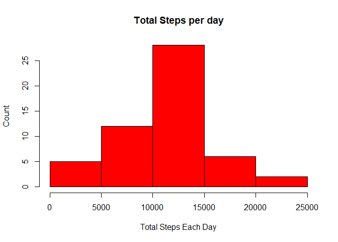

```r
dd <- na.omit(d)
dd <- aggregate(dd$steps, by=list(Date=dd$date), FUN=sum)
hist(dd$x, xlab="Total Steps Each Day", ylab="Count", main ="Total Steps per day", col="red")
```

- The mean total number of steps taken per day is:

```r
mean(dd$x)
```

```
## [1] 10766.19
```

- The median total number of steps taken per day is:

```r
median(dd$x)
```

```
## [1] 10765
```

## What is the average daily activity pattern?

1. Make a time series plot (i.e. type = “l”) of the 5-minute interval (x-axis) and the average number of steps taken, averaged across all days (y-axis)
2. Which 5-minute interval, on average across all the days in the dataset, contains the maximum number of steps?

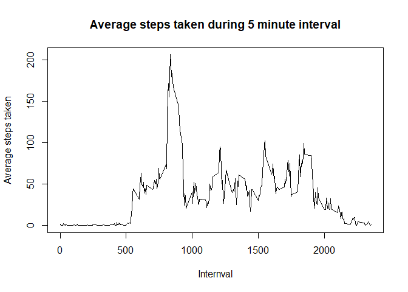

```r
d2 <- na.omit(d)
d5 <- aggregate(d2$steps, by=list(interval=d2$interval), FUN=mean)
plot(x=d5$interval, y=d5$x, type="l", ylab = "Average steps taken", xlab = "Internval", main = "Average steps taken during 5 minute interval")
```

The following interval

```r
d5$interval[which.max(d5$x)]
```

```
## [1] 835
```

contains the maximum number of steps.

## Imputing missing values

There are

```r
sum(is.na(d$steps))
```

```
## [1] 2304
```

missing values in the dataset.

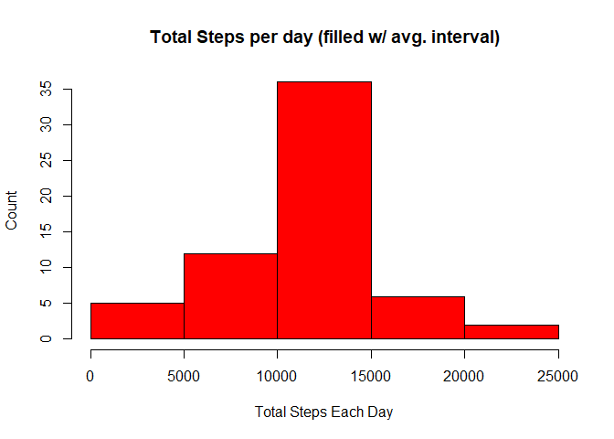

```r
d2 <- d
for (i in 1:nrow(d2))
{
  if (is.na(d2$steps[i]))
  {
     n <- which(d2$interval[i]==d5$interval)
     d2$steps[i] <- d5[n,]$x
  }
}
dd2 <- aggregate(d2$steps, by=list(Date=d2$date), FUN=sum)
hist(dd2$x, xlab="Total Steps Each Day", ylab="Count", main ="Total Steps per day (filled w/ avg. interval)", col="red")
```

* The mean total number of steps taken per day for this filled data set is:

```r
mean(dd2$x)
```

```
## [1] 10766.19
```

- The median total number of steps taken per day for this filled data set is:

```r
median(dd2$x)
```

```
## [1] 10766.19
```

## Are there differences in activity patterns between weekdays and weekends?

For this part the weekdays() function may be of some help here. Use the dataset with the filled-in missing values for this part.

1. Create a new factor variable in the dataset with two levels – “weekday” and “weekend” indicating whether a given date is a weekday or weekend day.
2. Make a panel plot containing a time series plot (i.e. type = “l”) of the 5-minute interval (x-axis) and the average number of steps taken, averaged across all weekday days or weekend days (y-axis). See the README file in the GitHub repository to see an example of what this plot should look like using simulated data.

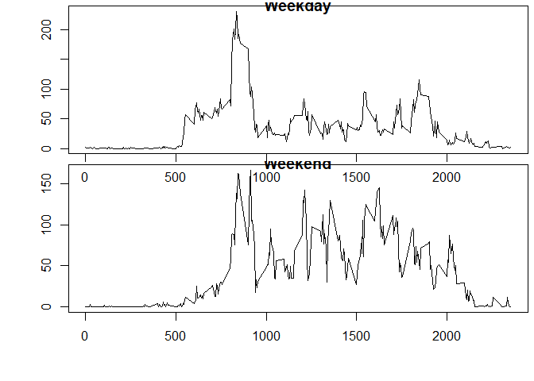

```r
d2$date <- as.Date(d2$date)
d2$day <- weekdays(d2$date)
d2$daytype <- "weekday"
d2$daytype[d2$day %in% c("Saturday", "Sunday")] <- "weekend"
d2wd <- subset(d2, d2$daytype == "weekday")
d2we <- subset(d2, d2$daytype == "weekend")
d5d2wd <- aggregate(d2wd$steps, by=list(Interval=d2wd$interval), FUN=mean)
d5d2we <- aggregate(d2we$steps, by=list(Interval=d2we$interval), FUN=mean)
par(mar=c(0.5, 0.5, 0.2, 0.2), mfrow=c(2,1),oma = c(4,4,0.2,0.2))
plot(x=d5d2wd$Interval, y=d5d2wd$x, type="l", ylab = "Average steps taken", xlab = "Internval", main = "Weekday")
plot(x=d5d2we$Interval, y=d5d2we$x, type="l", ylab = "Average steps taken", xlab = "Internval", main = "Weekend")
```